# 3.Detailed_analysis

Dennis Wiersma

2022-05-16

# Comparing simulation data with experimental data for two dosis

```r
data <- read.csv("MPL.csv", na.strings = "NA")

median_MPL_01 <- median(data$MPL_conc[data$dose==0.1], na.rm=T)
median_MPL_03 <- median(data$MPL_conc[data$dose==0.3], na.rm=T)

D01 = median_MPL_01 * 1000 / 374.471
D03 = median_MPL_03 * 1000 / 374.471
```

# Assignment 1

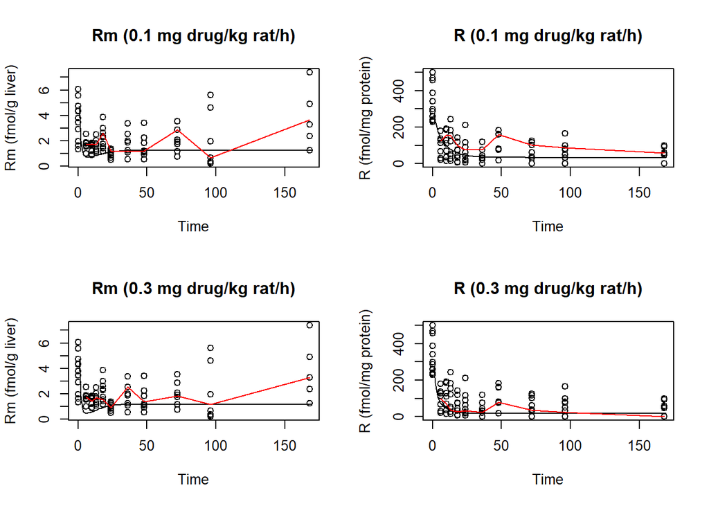

```r
parameters <- c(
  k.s_Rm = 2.90,
  IC.50_Rm = 26.2,
  k.on = 0.00329,
  k.T = 0.63,
  k.re = 0.57,
  Rf = 0.49,
  k.d_R = 0.0572,
  k.d_Rm = 0.612,
  k.s_r = 3.22,
  D = 0
)

state <- c(
  R.m0 = 4.74,
  R.0 = 267,
  DR = 0,
  DRN = 0
)

# glucocorticoid receptor dynamics
GRD <- function(t, state, parameters){
  with(as.list(c(state, parameters)),{

    dR.m <- k.s_Rm * (1 - DRN / (IC.50_Rm + DRN) - k.d_Rm * R.m0)

    dR <- k.s_r * R.m0 + Rf * k.re * DRN - k.on * D * R.0 - k.d_R * R.0

    dDR <- k.on * D * R.0 - k.T * DR

    dDRN <- k.T * DR - k.re * DRN

    return(list(c(dR.m, dR, dDR, dDRN)))
  }
  )
}

# Duration of 7 days, defined in hours
times <- seq(0, 168)

# Median values of experimental data per time value
medians <- aggregate(data[,c("MPL_conc","mRNA","Free_receptor")],
                     list(data$dose,data$time), median, na.rm=T)
names(medians)[1:2] <- c("dose","time")

# Sets parameter D to value for 0.1 mg drug/kg rat/h value
parameters["D"] = D01
# Performs the modelling function
out01 <- ode(y = state, times = times, func = GRD, parms = parameters)

# Sets parameter D to value for 0.3 mg drug/kg rat/h value
parameters["D"] = D03
# Performs the modelling function
out03 <- ode(y = state, times = times, func = GRD, parms = parameters)

par(mfrow = c(2,2))
# Plots a scatter plot with experimental data for Rm where dose == 0.1 mg drug/kg rat/h
plot(data$mRNA ~ data$time,
     main = "Rm (0.1 mg drug/kg rat/h)",
     ylab = "Rm (fmol/g liver)",
     xlab = "Time")
# Adds the model for Rm as a black line
lines(out01[,2])
# Adds medians of the experimental data for Rm as a red line
lines(medians[medians["dose"] == 0.1,]$mRNA ~ medians[medians["dose"] == 0.1,]$time,
      col = "red")

# Plots a scatter plot with experimental data for R where dose == 0.1 mg drug/kg rat/h
plot(data$Free_receptor ~ data$time,
     main = "R (0.1 mg drug/kg rat/h)",
     ylab = "R (fmol/mg protein)",
     xlab = "Time")
# Adds the model for R as a black line
lines(out01[,3])
# Adds medians of the experimental data for R as a red line
lines(medians[medians["dose"] == 0.1,]$Free_receptor ~ medians[medians["dose"] == 0.1,]$time,
      col = "red")

# Plots a scatter plot with experimental data for Rm where dose == 0.3 mg drug/kg rat/h
plot(data$mRNA ~ data$time,
     main = "Rm (0.3 mg drug/kg rat/h)",
     ylab = "Rm (fmol/g liver)",
     xlab = "Time")
# Adds the model for Rm as a black line
lines(out03[,2])
# Adds medians of the experimental data for Rm as a red line
lines(medians[medians["dose"] == 0.3,]$mRNA ~ medians[medians["dose"] == 0.3,]$time,
      col = "red")

# Plots a scatter plot with experimental for R data where dose == 0.3 mg drug/kg rat/h
plot(data$Free_receptor ~ data$time,
     main = "R (0.3 mg drug/kg rat/h)",
     ylab = "R (fmol/mg protein)",
     xlab = "Time")
# Adds the model for R as a black line
lines(out03[,3])
# Adds medians of the experimental data for R as a red line
lines(medians[medians["dose"] == 0.3,]$Free_receptor ~ medians[medians["dose"] == 0.3,]$time,
      col = "red")
```

## Questions 1: To determine whether the experimental data aligns with the model that has been made. This could show whether the model which has been made is applicable to practical experimental results, and whether or not it can be used to predict future results.

2: The amount of receptors (R) as a function of time is very dependent on the value of D. The more D is present in the system, the faster the receptors get saturated. The R values drop significantly faster as a result when increasing the dose of D.

The Rm (mRNA) values are way less responsive to a significant change in the D value. It hits equilibrium around the same time.

3: They’re not very in line, because there’s not enough experimental data to construct a reliable model. For example, at each moment of assessment only 5 measurements have been taken. Had there been more, then they would’ve overlapped more consistently.

# Assignment 2

```r
library(deSolve)

MPL.ngml <- 20

parameters <- c(
  k.s_Rm = 2.90,
  IC.50_Rm = 26.2,
  k.on = 0.00329,
  k.T = 0.63,
  k.re = 0.57,
  Rf = 0.49,
  k.d_R = 0.0572,
  k.d_Rm = 0.612,
  k.s_r = 3.22,
  D = MPL.ngml * 1000 * 1 / 374.477
)

state <- c(
  R.m0 = 4.74,
  R.0 = 267,
  DR = 0,
  DRN = 0
)
```

## Question 1

If we want to remove the influence DRN has on R.m, we’ll have to remove DRN from the formula which calculates dR.m. Doing this removes the negative feedback loop which would otherwise decrease mRNA synthesis. This yields a higher point of equilibrium for the activated drug-receptor complex. You can see this happen in the graphs below.

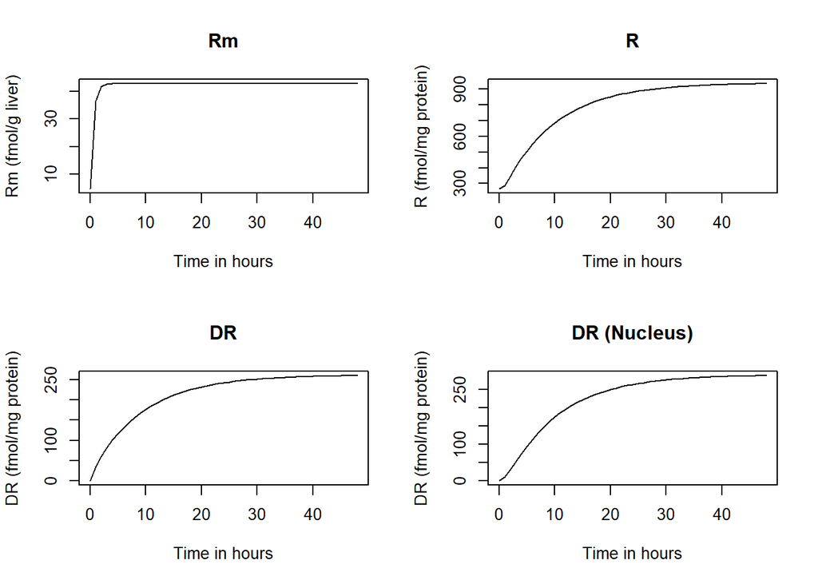

```r
# glucocorticoid receptor dynamics
GRD <- function(t, state, parameters){
  with(as.list(c(state, parameters)),{

    # Removed DRN's influence on R.m
    dR.m <- k.s_Rm * (IC.50_Rm - k.d_Rm * R.m0)

    dR <- k.s_r * R.m0 + Rf * k.re * DRN - k.on * D * R.0 - k.d_R * R.0

    dDR <- k.on * D * R.0 - k.T * DR

    dDRN <- k.T * DR - k.re * DRN

    return(list(c(dR.m, dR, dDR, dDRN)))
  }
  )
}

# Duration of 2 days, defined in hours
times <- seq(0, 48)

out <- ode(y = state, times = times, func = GRD, parms = parameters)

plot(out, xlab = "Time in hours", ylab = c("Rm (fmol/g liver)", "R (fmol/mg protein)",
                                           "DR (fmol/mg protein)", "DR (fmol/mg protein)"),
     main = c("Rm", "R", "DR", "DR (Nucleus)"))
```

## Question 2

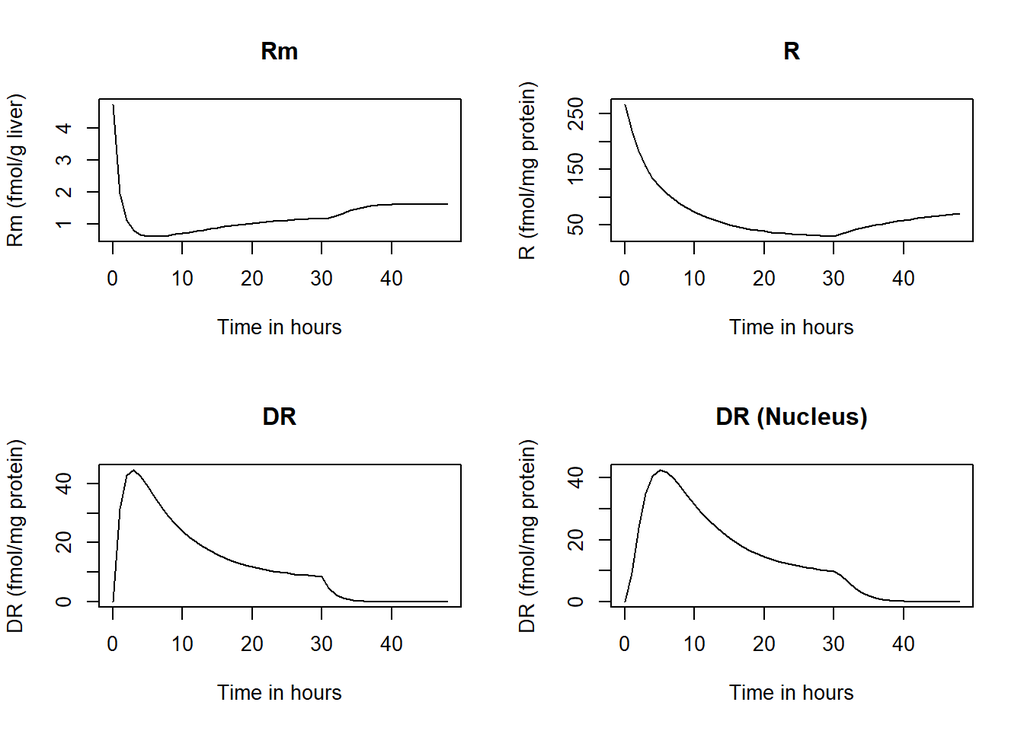

```r
MPL.ngml <- 20

parameters <- c(
  k.s_Rm = 2.90,
  IC.50_Rm = 26.2,
  k.on = 0.00329,
  k.T = 0.63,
  k.re = 0.57,
  Rf = 0.49,
  k.d_R = 0.0572,
  k.d_Rm = 0.612,
  k.s_r = 3.22,
  D = MPL.ngml * 1000 * 1 / 374.477
)

state <- c(
  R.m0 = 4.74,
  R.0 = 267,
  DR = 0,
  DRN = 0
)

# glucocorticoid receptor dynamics
GRD <- function(t, state, parameters){

  with(as.list(c(state, parameters)),{

    D <- ifelse(t > 30, 0, D)

    dR.m <- k.s_Rm * (1 - DRN / (IC.50_Rm + DRN) - k.d_Rm * R.m0)

    dR <- k.s_r * R.m0 + Rf * k.re * DRN - k.on * D * R.0 - k.d_R * R.0

    dDR <- k.on * D * R.0 - k.T * DR

    dDRN <- k.T * DR - k.re * DRN

    return(list(c(dR.m, dR, dDR, dDRN)))
  }
  )
}

# Duration of 2 days, defined in hours
times <- seq(0, 48)

out <- ode(y = state, times = times, func = GRD, parms = parameters)

plot(out, xlab = "Time in hours", ylab = c("Rm (fmol/g liver)", "R (fmol/mg protein)",
                                           "DR (fmol/mg protein)", "DR (fmol/mg protein)"),
     main = c("Rm", "R", "DR", "DR (Nucleus)"))
```

As you can see in the figure above, both Rm and R increase and stabilise at a higher level, while DR and DRN do the exact opposite. When we remove our reactant D, DR decreases since it can’t be synthesised anymore. The same is true for DRN since it needs DR to form. Now that there is less DRN present in the system, Rm production isn’t inhibited any longer. Therefore, it’s concentration will increase and balance out at a new, higher equilibrium. The concentration of R will follow a similar pattern since Rm is now present at a higher concentration, and there is no more D available to bind to R.

## Question 3

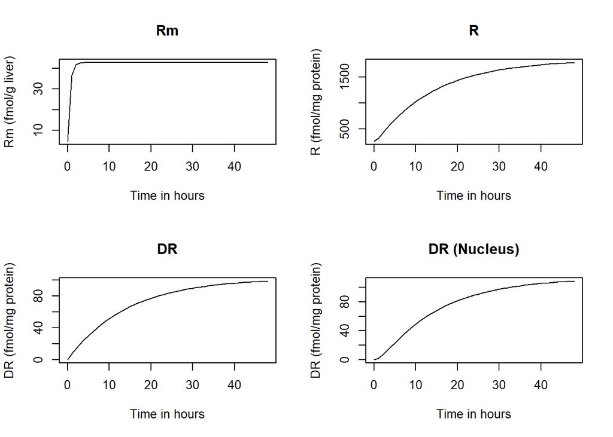

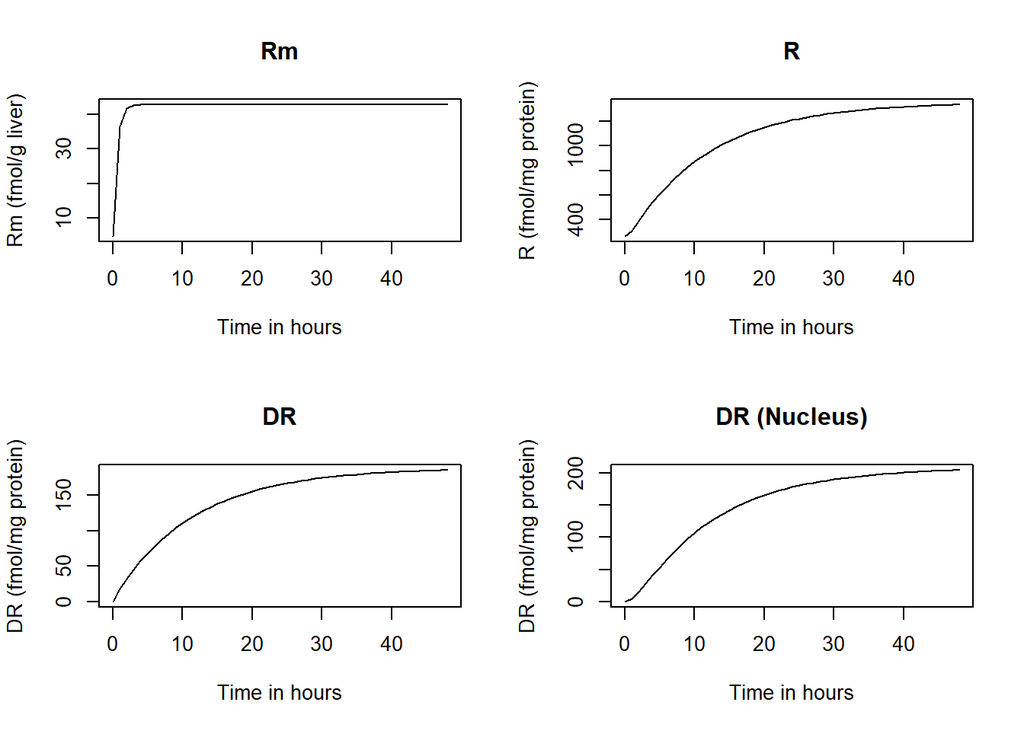

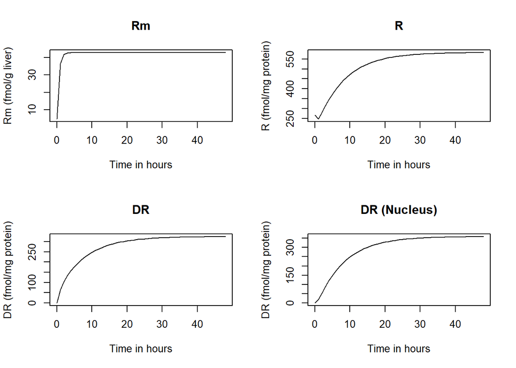

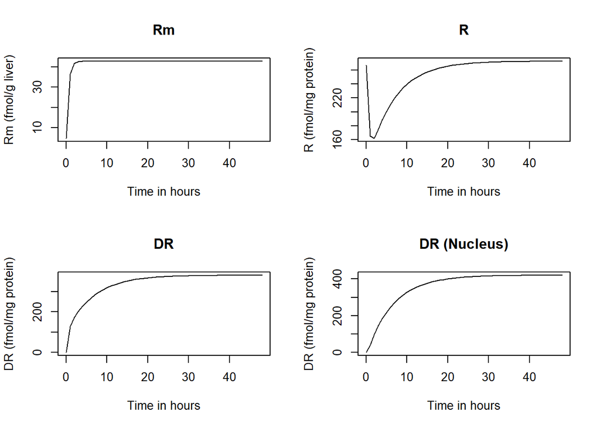

```r
GRD <- function(t, state, parameters){
  with(as.list(c(state, parameters)),{

    # Removed DRN's influence on R.m
    dR.m <- k.s_Rm * (IC.50_Rm - k.d_Rm * R.m0)

    dR <- k.s_r * R.m0 + Rf * k.re * DRN - k.on * D * R.0 - k.d_R * R.0

    dDR <- k.on * D * R.0 - k.T * DR

    dDRN <- k.T * DR - k.re * DRN

    return(list(c(dR.m, dR, dDR, dDRN)))
  }
  )
}

k.on_var <- c(0.00329/5, 0.00329/2, 0.00329*2, 0.00329*5)
k.re_var <- c(0.57/5, 0.57/2, 0.57*2, 0.57*5)

for (val in k.on_var){
  parameters["k.on"] = val
  out <- ode(y = state, times = times, func = GRD, parms = parameters)
  plot(out, xlab = "Time in hours", ylab = c("Rm (fmol/g liver)", "R (fmol/mg protein)",
                                             "DR (fmol/mg protein)", "DR (fmol/mg protein)"),
       main = c("Rm", "R", "DR", "DR (Nucleus)"))
  parameters["k.on"] = 0.00329
}
```

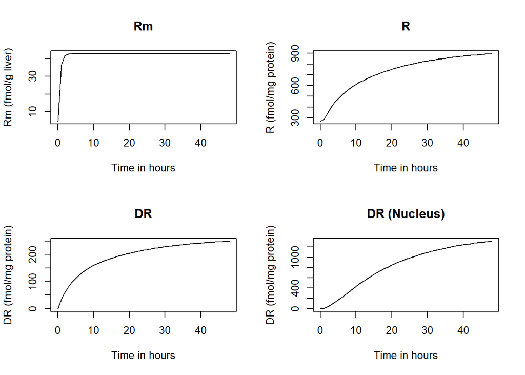

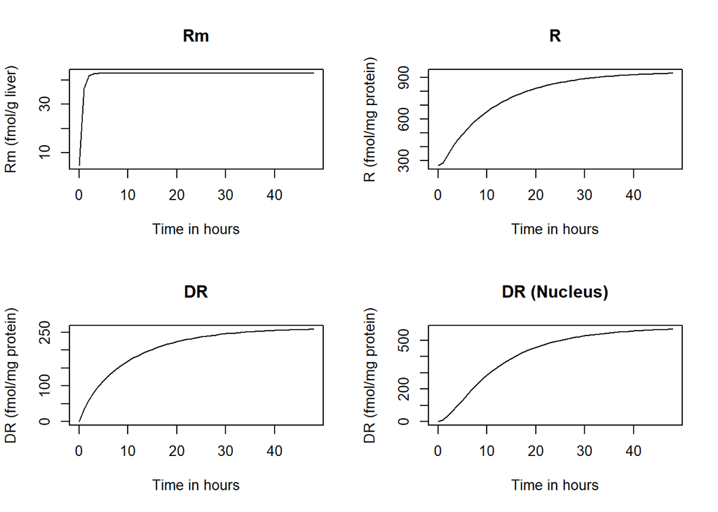

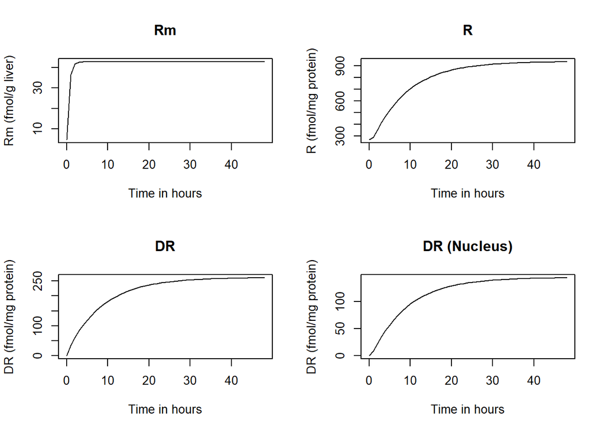

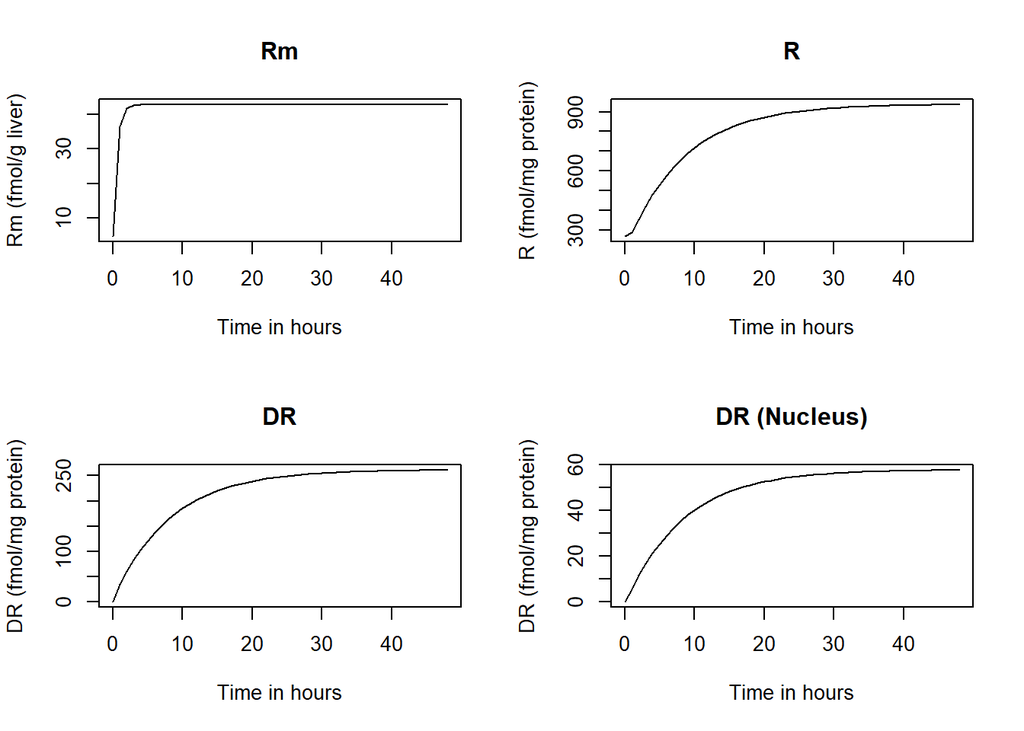

```r
for (val in k.re_var){
  parameters["k.re"] = val
  out <- ode(y = state, times = times, func = GRD, parms = parameters)
  plot(out, xlab = "Time in hours", ylab = c("Rm (fmol/g liver)", "R (fmol/mg protein)",
                                             "DR (fmol/mg protein)", "DR (fmol/mg protein)"),
       main = c("Rm", "R", "DR", "DR (Nucleus)"))
  parameters["k.re"] = 0.57
}
```

Chaning the k.on values results in different slopes. The lower the value the slower R reaches its peak and equilibrium, compared to the default value. This goes for all but Rm in the plots. This can be explained because the total amount of mRNA would not be affected by the rates.

## Question 4

To completely block the synthesis of receptors, k.s_r would have to put to 0, because then the synthesis of the receptors would completely stop.

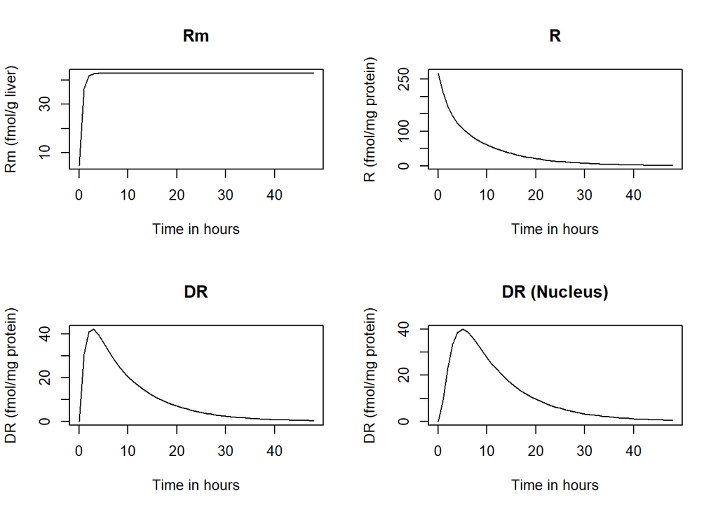

```r
parameters["k.s_r"] = 0
out <- ode(y = state, times = times, func = GRD, parms = parameters)

plot(out, xlab = "Time in hours", ylab = c("Rm (fmol/g liver)", "R (fmol/mg protein)",
                                           "DR (fmol/mg protein)", "DR (fmol/mg protein)"),
     main = c("Rm", "R", "DR", "DR (Nucleus)"))
```

```r
parameters["k.s_r"] = 3.22
```

R just reduces to 0, as can be seen in the plot.

## Question 5:

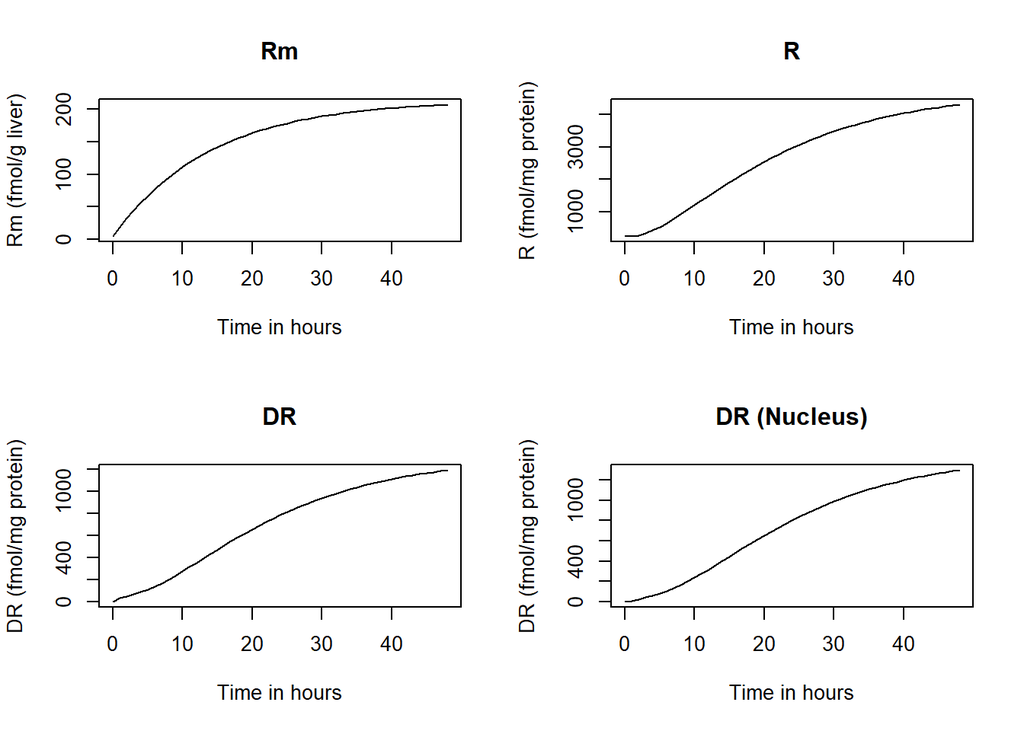

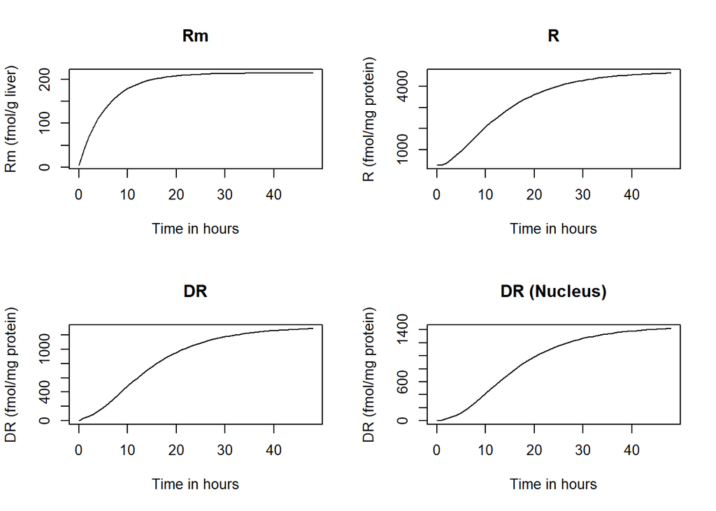

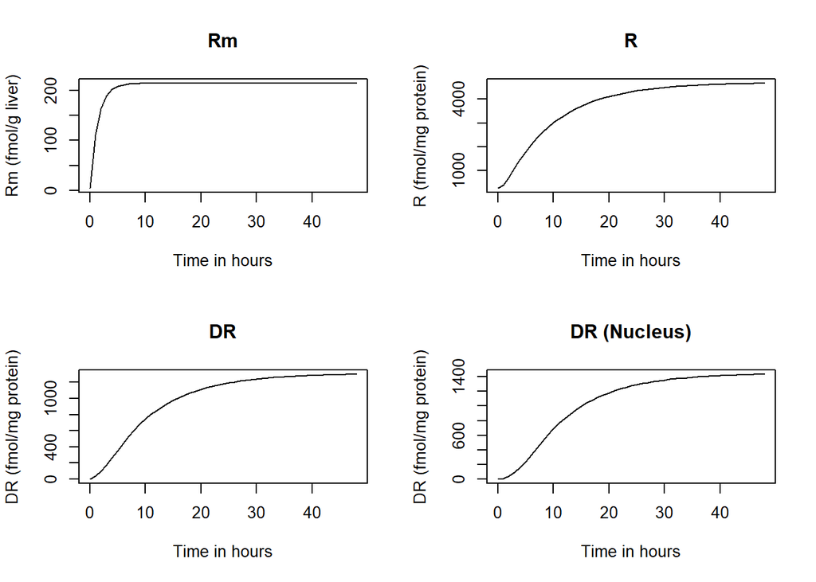

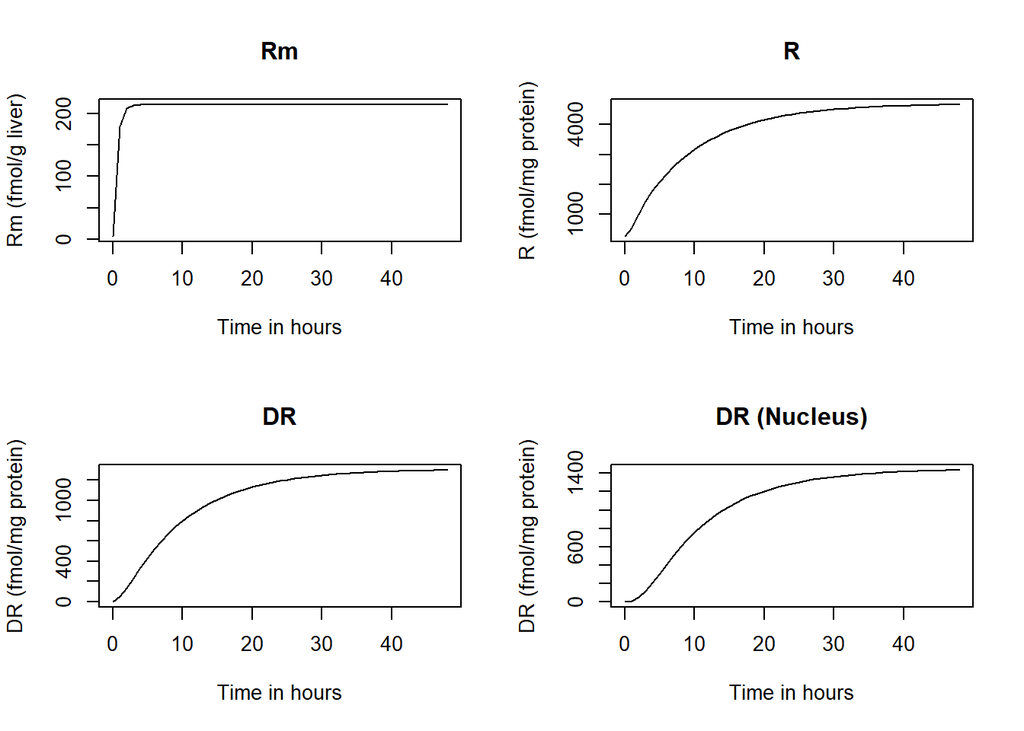

```r
ks_Rm.var = c(2.9/5, 2.9/2, 2.9*2, 2.9*5)
kd_Rm.var = c(2.9/5/4.74, 2.9/2/4.74, 2.9*2/4.74, 2.9*5/4.74)
i = 0

for (val in ks_Rm.var){
  i  =+ 1
  parameters["k.s_Rm"] = val
  parameters["k.d_Rm"] = kd_Rm.var[i]
  out <- ode(y = state, times = times, func = GRD, parms = parameters)
  plot(out, xlab = "Time in hours", ylab = c("Rm (fmol/g liver)", "R (fmol/mg protein)",
                                             "DR (fmol/mg protein)", "DR (fmol/mg protein)"),
       main = c("Rm", "R", "DR", "DR (Nucleus)"))
}
```